# Day 2: Heatmaps and small multiples

# Exercise 2: small multiples

In this exercise we will analyse mental wellbeing in the different European countries.

The index has range 0-100.

To do so, we will look at differences in distribution between countries.

Let’s start with a simple plot with one density distribution plot for each country.

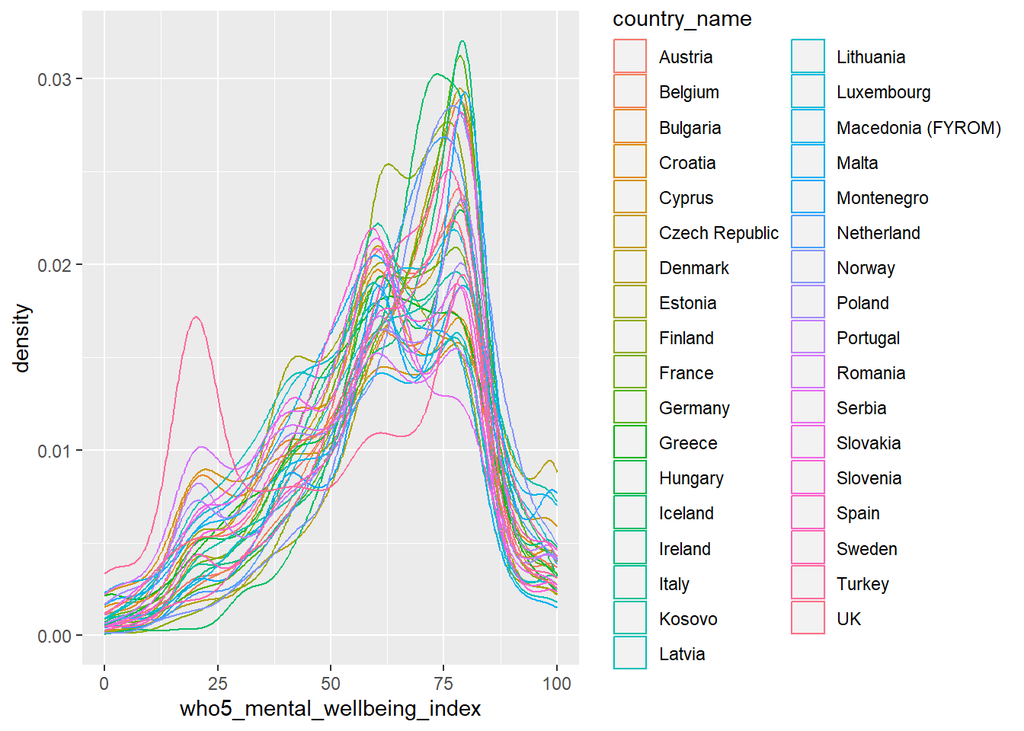

```r
# Density distribution plot
ggplot(data = qol, aes(x = who5_mental_wellbeing_index, group = country_name, color = country_name)) +
  geom_density()
```

You will notice that it is not so easy to perceive differences between countries from this plot.

To solve that issue, let’s do small multiples for each country!

You might need to put in extra work to adjust each panel, e.g., by putting a different colour for each panel

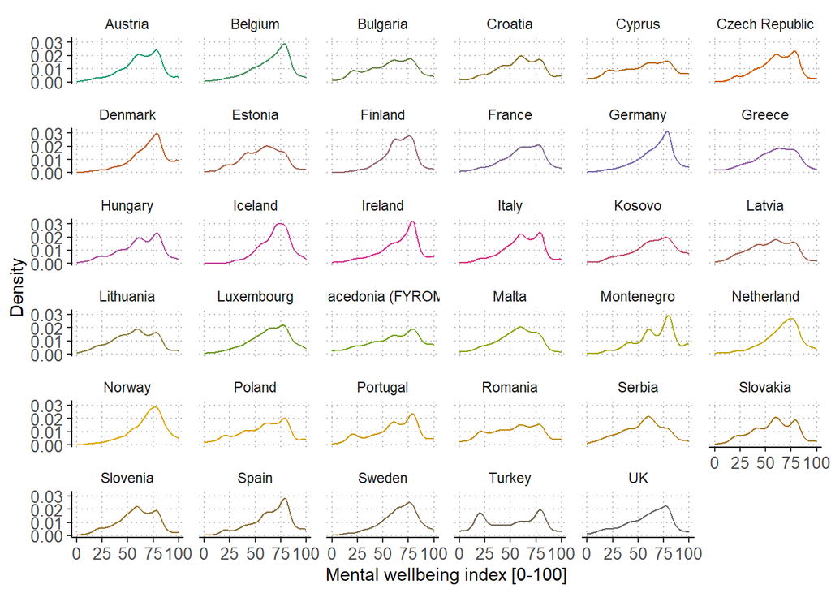

```r
# Extend palette to more colours
palette <- brewer.pal(8L, "Dark2")
big_palette <- colorRampPalette(palette)(length(unique(qol$country_name)))

ggplot(data = qol, aes(x = who5_mental_wellbeing_index, color = country_name)) +
  geom_density() + # Density
  facet_wrap(~country_name) +
  theme_classic() +
  theme(
    panel.grid.major = element_line(color = "gray", linetype = "dotted"), # Grid
    axis.text.x = element_text(size = 10L), # Font size x axis
    axis.text.y = element_text(size = 10L), # Font size y axis
    legend.position = "topleft", # Legend position
    strip.background = element_blank(), # Remove borders from title
    panel.margin = unit(0.33, "cm") # Increase margin between subplots
  ) +
  labs(
    x = "Mental wellbeing index [0-100]", # Rename x label
    y = "Density" # Rename y label
  ) +
  scale_color_manual(values = big_palette) # Add color bar and palette
```

# Exercise 3: heatmaps

In this exercise we will analyse whether there are different patterns in Internet usage.

Select all the columns referring to the Internet (i.e., containing the keyword “internet”), and plot a heatmap to visualise potential differences between countries.

```r
# Select columns with "internet" or starting with "country_name"
selected_columns <- qol %>%
  select(matches("internet|^country_name"))

# Drop rows with missing values and calculate the mean by country_name
summary <- selected_columns %>%
  drop_na() %>%
  group_by(country_name) %>%
  summarise(across(everything(), mean))

# Rename columns
summary <- summary %>%
  rename_with(
    ~ gsub("phone_internet_contact_with_", "", .), # Remove "phone_internet_contact_with" from column names
    everything()
  ) %>%
  rename(
    # rename the column "how_frequently_use_the_internet_other_than_for_work"
    other_than_work = how_frequently_use_the_internet_other_than_for_work
  )

head(summary)
```

```
## # A tibble: 6 × 6
##   country_name   children parents other_relatives neighbours other_than_work
##   <chr>             <dbl>   <dbl>           <dbl>      <dbl>           <dbl>
## 1 Austria            2.73    3.97            2.97       2.46            3.00
## 2 Belgium            2.85    4.02            3.19       2.99            2.61
## 3 Bulgaria           3.14    4.56            3.51       2.67            3.98
## 4 Croatia            1.69    2.22            2.35       2.17            3.16
## 5 Cyprus             2.53    3.74            2.18       2.17            3.90
## 6 Czech Republic     2.78    4.05            3.26       2.88            3.02
```

```r
# Matrix without the first column (country_name)
heatmap_matrix <- as.matrix(summary[, -1L])

# Define row and column names
rownames(heatmap_matrix) <- summary$country_name
colnames(heatmap_matrix) <- colnames(heatmap_matrix)

# Order rows alphabetically
ordered_rows <- rownames(heatmap_matrix)[order(rownames(heatmap_matrix))]

# Reorder the rows of the heatmap_matrix
heatmap_matrix_ordered <- heatmap_matrix[rev(ordered_rows), ]

head(heatmap_matrix_ordered)
```

```
##          children  parents other_relatives neighbours other_than_work
## UK       2.743682 4.008424        3.034296   2.670277        2.512034
## Turkey   2.703883 2.833738        2.754854   2.603155        3.978155
## Sweden   2.642746 4.012480        2.967239   2.151326        1.784711
## Spain    3.324975 4.157472        3.169509   2.833501        3.587763
## Slovenia 2.808357 4.136888        2.927954   2.180115        3.093660
## Slovakia 2.618987 4.169620        2.977215   2.453165        3.203797
```

```r
# Number of colours (high value so we get something approximately continuous)
n_colors <- 100L

# Max and min of the color bar
vmin <- 1L
vmax <- 6L

# Heatmap saved as pcardio_train
pheatmap(
  heatmap_matrix_ordered,
  angle_col = 45L, # Angle for column ticks
  treeheight_row = 0L, # Remove dendrogram
  treeheight_col = 0L, # Remove dendrogram
  col = colorRampPalette(c("#c13639", "white", "#2f79b5"))(n_colors),
  breaks = seq(vmin, vmax, length.out = n_colors + 1L),
  filename = "../img/heatmap_day2.pdf" # Save as Pcardio_train
)
```